# Biblio and research questions

- Database to add:
  - USGS: https://www.sciencebase.gov/catalog/item/529e0108e4b0516126f68e3c

# 1 Introduction

## 1.1 Treats on streams

- Land-use changes: (**piet_climate_2010?**) in Climate change …
  - Forest vs drained = retained water vs greater run-off
  - River morphology: canalization, lost of connection
- Climate change on stream hydrology:(**piet_climate_2010?**)
  - More variable discharge regimes (south england): higher peaks in winters (less winter droughts)
    - higher flow redistributes resources homogenize water chemestry
    - lower flow: less oxygen, dried banks -> decrease stability
- Temperature and hydrological factors on fishes: (**hering_monitoring_2010?**)
  - changes of rivers discharges: decrease species richness and change life cycles
  - Increasing temperature: threat to cold stenothermic species, confined in headwaters due to the reduction of available cold waters

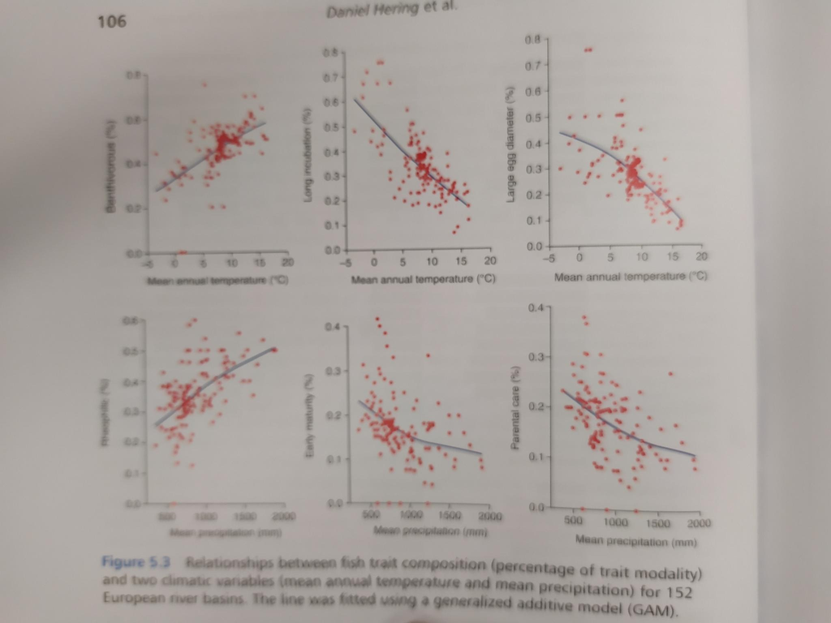

Figure 1.1: fig/fish-trait-composition-temperature-rainfall-europe

```r
knitr::include_graphics(
  here::here("doc/fig/fish-trait-composition-temperature-rainfall-europe.jpeg")
)
```

- Acidication due to emission of S and N in the atmosphere (**wright_interaction_2010?**)
  - Highest pick in the 1980’s, particularly severe in scandinavia
  - Dramatic reduction after worldwide agreement on S and N emission (goal in 1999: -50% S and -20% N in 2010 relative to 1980)
  - increasing temperature: accelerated mineralization and increase of acidification
- Freshwater ecology: a scientific introduction
  - Get a look from chapter 5 to 10
- Conservation biology: to read

## 1.2 Biodiversity

- Land-use change and species climatic tolerance:
  - loss of semi-natural habitat leaded to faster declines of thermal sensitive fishes (Williams et al. 2021)
  - temperature differences linked to land-use (average daily maximum temperature)

# 2 Research questions

- Biodiversity:
  - facets of biodiversity trends
  - Biodiversity index
  - species characteristics
- Biological scale:
  - Population: LPI
  - Community: CWM, extirpation, colonisation
  - Metacommunity: homogenization (betadiv)?
- climatic debts:
  - (Vaughan and Gotelli 2019, 2021)
1. How do community of freshwater change through time ?
   - Scale community / population
   - Quantity / Heterogeneity

# 3 Methods

## 3.1 Data selection

- Check the utility functions of `codyn`:

```r
source("https://raw.githubusercontent.com/NCEAS/codyn/master/R/utilities.R")
check_single_onerep
```

### 3.1.1 Spatial scale

### 3.1.2 Script of Lise to select Basin

```r
select_data <- continuous_data[
  continuous_data$span >= 10 & continuous_data$completeness >= 0.8,
  ]
```

- Select basin that have at least 5 sites:

```r
#////////////////////////////////////////
#select basins with at least 5 sites
    data_basins <- NULL
    for (oo in levels(select_data_all$ORIGIN)) {
      dat_sel <- select_data_all[select_data_all$ORIGIN == oo, ]
      tab <- table(dat_sel$MAIN_BAS)
      keep <- names(which(tab >= 5))
      data_basins <- rbind(data_basins, dat_sel[dat_sel$MAIN_BAS %in% keep, ])
    }
```

- Over the basin, find the nb of (op / sites) by year and by basin to find the optimal period of sampling, i.e. max(year) - min(year) with the most sampling
  - Keep by basin site span 10 years of data
  - Keep by basin the year with the maximum number of sampled sites

```r
for (idx in 1:totalNbas) {
  select_data <- data_basins[data_basins$MAIN_BAS == ID[idx], ]

  data_summary <- NULL

  for (ii in min(select_data$begin):max(select_data$begin)) {

    for (jj in min(select_data$end):max(select_data$end)) {

      dat_sel <- select_data[select_data$begin <= ii & select_data$end >= jj, ]
      span <- jj - ii + 1

      data_summary <- rbind(
        data_summary,
        data.frame(BEG = ii, END = jj, SPAN = span, NB = nrow(dat_sel))
      )
    }
  }

  data_summary <- data_summary[data_summary$SPAN >= 10, ]
  RES <- rbind(RES, data.frame(MAIN_BAS = ID[idx], data_summary[which.max(data_summary$NB), ]))
}
```

- With the period most sampled by basin
  - Keep the basins that have at leat 5 sites in this period

```r
data_basins <- read.table("Segments_per_basin.txt", h = T)

select_basins <- NULL
for (idx in 1:nrow(RES)) {
  selec <- data_basins[
    data_basins$MAIN_BAS == RES$MAIN_BAS[idx] &
      data_basins$begin <= RES$BEG[idx] &
      data_basins$end >= RES$END[idx],
    ]

  if (nrow(selec) >= 5) {
    select_basins <- rbind(select_basins, selec)
  }
}
```

- By site:
  - Check that the consecutive temporal series, non consecutive if more than two years between two samplings
  - Compute span and completeness for each consecutive segment of each site

```r
x <- seq(10)
s <- split(x, cumsum(c(TRUE, diff(x) > 2)))
s
```

```
#> $`1`
#>  [1]  1  2  3  4  5  6  7  8  9 10
```

```r
x <- x[!x %in% c(3, 4, 5)]
s <- split(x, cumsum(c(TRUE, diff(x) > 2)))
s
```

```
#> $`1`
#> [1] 1 2
#>
#> $`2`
#> [1]  6  7  8  9 10
```

```r
sapply(s, length)
```

```
#> 1 2
#> 2 5
```

```r
continuous_data <- NULL
for (kk in 1:length(files)) {
  fishdata <- read.table(files[kk], h = T)

  fishdata$Abundances <- as.numeric(fishdata$Abundances)

  summarized_fishdata <- fishdata %>%
    group_by(sYNGEO_ID, Year) %>%
    summarise(Total_abund = sum(Abundances, na.rm = T))

  totalNsites <- length(unique(summarized_fishdata$sYNGEO_ID))
  print(c(totalNsites, length(unique(fishdata$SiteID))))
  ID <- unique(summarized_fishdata$sYNGEO_ID)

  for (idx in 1:totalNsites) {
    df <- summarized_fishdata %>%
      subset(sYNGEO_ID == ID[idx])
    site_no <- ID[idx]

    x <- df$Year
    s <- split(x, cumsum(c(TRUE, diff(x) > 2)))
    nb <- sapply(s, length)
    begin <- sapply(s, min)
    end <- sapply(s, max)
    span <- end - begin + 1
    completeness <- nb / span

    continuous_data <- rbind(
      continuous_data,
      data.frame(
        sYNGEO_ID = as.character(ID[idx]),
        # segment=rep(1:length(s)),
        begin,
        end,
        span,
        completeness,
        unique(
          chara[
            chara$sYNGEO_ID == as.character(ID[idx]) &
              chara$Origin == as.character(unique(fishdata$Origin)),
            c(1, 8, 9, 13:15)
            ]
        )
      )
    )

  }
}
```

- Check problem:
  - Check which consecutive segments has completeness inferior to 80%
  - By basin:
    - remove segments that do not repect completeness ? i.e. keep sevel several segements by sites ?
    - remove basin that has less than 5 sites after segments selection
    - *Note: no selection on the length of the segements ?*

```r
BAS_pb <- NULL
pb <- continuous_data[which(continuous_data$completeness < 0.8), ]
pb_basin <- unique(pb$MAIN_BAS)
for (ii in pb_basin) {
  dat_pb <- read.table(files[grep(ii, files)])
  enl <- pb$sYNGEO_ID[pb$MAIN_BAS == ii]
  dat_pb <- dat_pb[-which(dat_pb$sYNGEO_ID %in% enl), ]
  aa <- nlevels(factor(dat_pb$SiteID))
  if (aa < 5) {
    BAS_pb <- c(BAS_pb, as.character(ii)) # no sites
  }
  write.table(dat_pb, files[grep(ii, files)], row.names = FALSE, sep = "\t")
}
```

```r
continuous_data <- continuous_data[
  -which(
    continuous_data$completeness < 0.8 | continuous_data$MAIN_BAS %in% BAS_pb
  ), ]
write.table(
  continuous_data,
  "sites_selection_basins_stability.txt", sep = "\t",
  row.names = FALSE)
```

- **Summary** (from what I believe I understood):
  1. Select sites that span at least 10 years and completeness >= 0.8
  2. Select basins that have 5 sites at least
  3. Find optimal sampled period by basin:
     - combination of `min(year)` and `max(year)` with the most sampling
  4. By basin
     1. select site in most sampled period
     2. select basins that have at least 5 sites
  5. Separate non consecutive segments by sites:
  6. Select segments which have completeness > .8
  7. Several segments by site ?
  8. Keep basin with at least 5 sites
- I am not sure that the sites are same each year in each basin with this selection
- What is average number of site by year?

## 3.2 Environmental characteristics

- Site protection status:
  - US database, Australian database
  - [wdpar R package](https://prioritizr.github.io/wdpar/)
- Land use:
  - biais in studied land-use types in ecology: Martin, Blossey, and Ellis (2012)
  - from 1700 to 2000: https://ecotope.org/anthromes/v2/
  - Anthropogenic land use estimates for the Holocene – HYDE 3.2: -10000 to 2015: https://essd.copernicus.org/articles/9/927/2017/essd-9-927-2017.html, https://essd.copernicus.org/articles/9/927/2017/essd-9-927-2017.html
    - (1,000 y increments from 10,000 BCE to 1 CE, 100 y increments from 100 CE to 1700 CE, 10 y increments from 1710 to 1990 CE, and 1 y increments from 2000 CE to 2017 CE).
    - HYDE1 https://agupubs.onlinelibrary.wiley.com/doi/pdf/10.1029/1999GB001232
    - Copernicus land cover 2016 to 2020: https://github.com/bluegreen-labs/ecmwfr
    - 1995 à 2015 ESA: https://catalogue.ceda.ac.uk/uuid/b382ebe6679d44b8b0e68ea4ef4b701c
- Riveratlas: See `L://ENV_LAYERS`
- Water temperature:`L://ENV_LAYERS`
- Air temperature: chelsa

# 4 Biodiversity

## 4.1 LPI

### 4.1.1 Get data

#### 4.1.1.1 Chain method

Chain method is for poor timeseries with (n < 6) (Collen et al. 2009).

$i$: a population $j$: a species $t$: a time step

$d_{i,j,t} = \log_{10}(\dfrac{N_{i,j,t}}{N_{i,j,t-1}}) = \log_{10}N_{i,j,t} - \log_{10}N_{i,j,t-1}$

where $N_t$ is the abundance of a given population $i$ of the species $j$ at time $t$.

One percent of the mean population measure value for the whole time series was added to all years in time series for which N was zero in any year. Missing values were imputed with log-linear interpolation:

$N_t = N_p (\dfrac{N_s}{N_p})^{\dfrac{t-s}{s-p}}$

with $p$ the previous time step with measured value and $s$ the subsequent year with a measured value.

#### 4.1.1.2 GAM method

Set a GAM for each timeseries and report the predicted abundance values each year. There are rules of thumbs to automatically set the smoothing parameters (see Collen et al. 2009).

Following, $d_{i,j,t}$ are computed with the predicted abundance values.

### 4.1.2 LPI computation

If a species has several populations, the annual species trends is computed as the average[^1] of local population trends:

$d_{j,t} = \dfrac{1}{n}\sum_{i = 1}^{n} d_{i,j,t}$

It is a geometric mean because it the arithmetic mean of log transformed values of $N$:

$\sum_{i = 1}^{n} d_{i,j,t} = \sum_{i = 1}^{n} (\log_{10}N_{i,j,t} - \log_{10}N_{i,j,t-1})$

The standardized index for a species is then computed as:

$I_{j, t} = I_{j, t - 1} 10^{d_{j,t}}$, $I_0 = 1$

### 4.1.3 Confidence limits

Bootstrap on the selection of the $n_j$ population.

### 4.1.4 Misc

- LPI:
  - McRae, Deinet, and Freeman (2017); (**capdevila_global_2021?**)
  - [rlpi R package](https://github.com/Zoological-Society-of-London/rlpi)

#### 4.1.4.1 Note on the geometric mean: Buckland et al. (2011)

- Because it measures proportional changes, low change in absolute abundance in a rare species can lead a big change in the geometric mean
- Based on above, the geometric is linked to eveness

How $G_t$ is linked to eveness ?

$G_t = exp(\dfrac{1}{n} \sum_{i = 1}^{n} (\log N_{i,j,t} - \log N_{i,j,t-1}))$

If we look at multicative change in species proportion:

$\dfrac{p_{i,t}}{p_{i,t-1}} = exp((\log N_{j, t} - \log N_t) - (\log N_{j, t-1} - \log N_{t-1}))$

where $N_t = \sum_{j=1} N_{j,t}$

if $n$ stays constant between $G_t$ and $G_{t-1}$

If total abundances stays constant between years, i.e. $N_t = N_{t-1}$,

$\dfrac{p_{i,t}}{p_{i,t-1}} = exp(\log N_{j, t} - \log N_{j, t-1})$, then

$G_t = exp(\dfrac{1}{n} \sum_{i = 1}^{n} \log p_{i,j,t} - \dfrac{1}{n} \sum_{i = 1}^{n} \log p_{i,j,t-1})$

“The mean of the log species proportions has the key property of an evenness measure, in that it attains its maximum value when all the species proportions are equal: $p_{i,t} = 1/n$ for all $i$”.

### 4.1.5 Avantages

- Not biais for detectability variation between species
  - but biais if detectability change through time within species
- LPI change even if evenness stays the same (contrary to shannon and simpson)
- Linked to within-species (population) construction and reference to a baseline year:
  - no differences if units are abundance, biomass, density
  - combine trends of really different survey
- Rescale:
  - if a new survey began in 2000, the index of 2000 for the this new survey should be scaled to value of the composite index of 2000
  - if an abundant species become too rate to be included in the index, rescale as this: for the final year which the species is included compute the index with and without the species, the latter need to be rescale to match the former. Same rescaling is necessary for all subsequent years.

### 4.1.6 Disaventages

- Do not work when when relative abundance is 0:
  - one can add small numbers to 0 but the indice is sensible to the chosen quantity + poor precision with rarely recorded species.
  - Shannon and Simpson are not influenced by rare species
  - Problem can be reduced if observed count are modeled before index computation

### 4.1.7 Computation

- NA = 0 or missing values to interpolate ? It is 0 if a monitoring took place and that the species was missing

## 4.2 Quantity index

### 4.2.1 Rarefaction

- Chao and Jost (2012): A temperate-zone tree community with 10 species might be completely characterized by a sample of 100 individuals, but the same size sample would greatly underestimate the richness of a tropical rain forest with 300 tree species. If we compared the richnesses of these two communities using samples standardized to 100 individuals, the richnesses we obtain would not give a meaningful idea of the real degree of difference between the communities’ richnesses.

### 4.2.2 Coverage-based species richness (Chao and Jost 2012)

```r
x <- c(rep(.3, 1), rep(.1, 1), rep(.05, 3), rep(.01, 45))

# we sample 20 indiv randomly, imagine that we add the 12
#most abundant species:

sample1 <- x[1:12]
# proportion of individuals in the community that belongs to species that were
# represented in the sample:
coverage <- sum(sample1)
# proportion of individuals in the community that belongs to species that were
# NOT represented in the sample:
deficit_coverage <- 1 - coverage
```

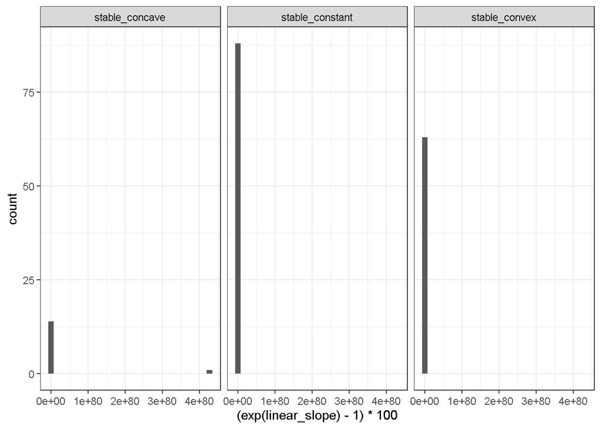

```r
# Polynome
tar_load(rigal_trends)
ti <- rigal_trends[[1]]
ti %>%
  filter(direction == "stable", linear_slope_pvalue < 0.05) %>%
  ggplot(aes(x = (exp(linear_slope) - 1) * 100)) +
  geom_histogram() +
  facet_grid(cols = vars(shape_class))
```

### 4.2.3 Hill numbers

- Chao: iNEXT, [BES paper](https://besjournals.onlinelibrary.wiley.com/doi/10.1111/2041-210X.12613)

```r
library(iNEXT)
data(spider)
```

```r
div_spider <- iNEXT::iNEXT(spider, q = c(0, 1, 2), datatype = "abundance")
```

- Hill numbers 0 (species richness), 1 (shannon), 2 (simpson)

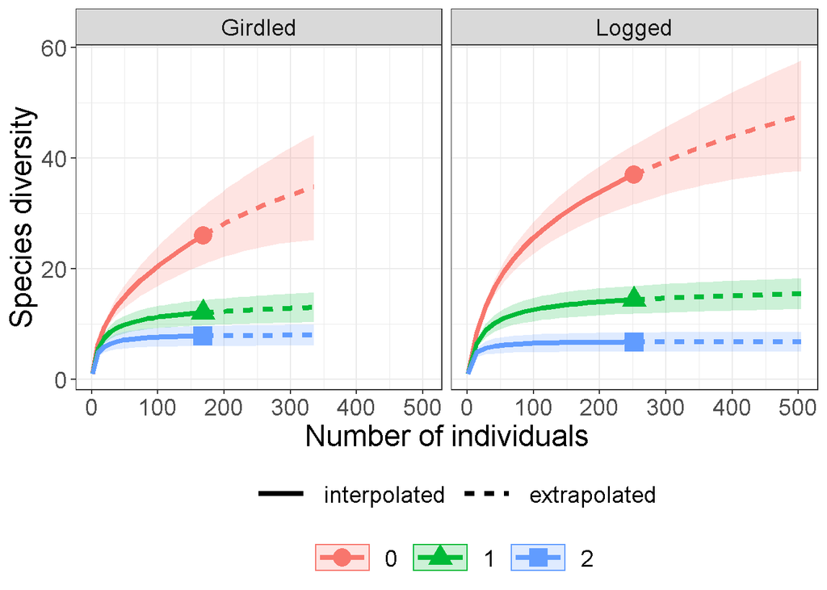

```r
ggiNEXT(div_spider, type = 1, facet.var = "site")
```

- Coverage based rarefaction/extrolation:

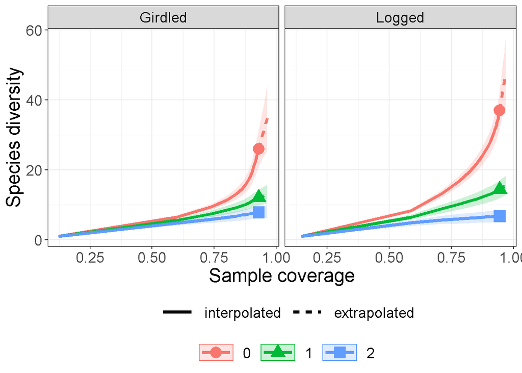

```r
ggiNEXT(div_spider, type = 3, facet.var = "site")
```

```r
tar_load(filtered_dataset)
fish <- filtered_dataset$measurement %>%
  filter(
    siteid == unique(siteid)[1],
    year == 2007
  )
div_fish <- iNEXT::iNEXT(fish$abundance, q = c(0, 1, 2), datatype = "abundance")
```

```r
test <- filtered_dataset$measurement %>%
  filter(op_id %in% unique(op_id)[1:2])
ti <- get_chao_hillnb(
  x = test,
  coverage = .985,
  confidence_int = NULL)
```

- Coverage based rarefaction/extrolation:

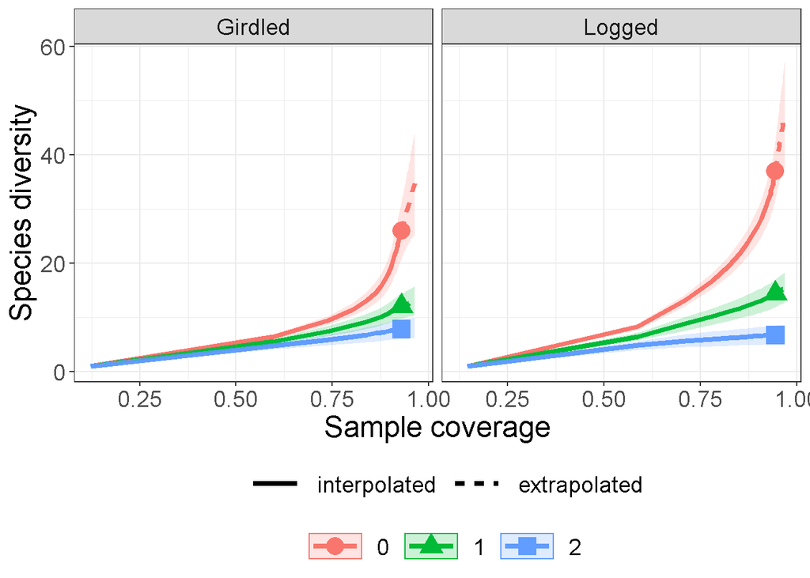

```r
ggiNEXT(div_spider, type = 3, facet.var = "site")
```

## 4.3 Compositional changes

- Multi-site based on presence/absence probability (Baeten et al. 2014)
  - Based on deviance:
    - $D_i = -2n [p_i\log(p_i) + (1-p_i)\log(1-p_i)]$
    - Omnipresent and rare species have the same contribution to the heterogeneity in community composition
- extirpation / colonisation:
  - Species exchange index:
    - $SER_r = \dfrac{S_{imm} + S_{lost}}{S_{tot}}$ based on presence absence
      - Implemented in [`codyn`](https://github.com/NCEAS/codyn)
    - $SER_a = \dfrac{\sum_i (p_i - p'_i)^2}{\sum_i p_i^2 + \sum_i p'_i^2 - \sum p_i p'_i}$
      - [See the math](https://besjournals.onlinelibrary.wiley.com/action/downloadSupplement?doi=10.1111%2F1365-2664.12959&file=jpe12959-sup-0005-AppendixS3.pdf)
      - Complement Jaccard index as: $J_a = 1-SER_a = S_{comm} / S_{tot}$
      - Here diversity is measured with the Simpson index: $\lambda = \sum_i{p_i^2}$  
        if all species are equally abundant: $\lambda = \sum_i \dfrac{1}{S}^2 = \dfrac{S}{S^2} = \dfrac{1}{S}$ so $S = \dfrac{1}{\lamda}$
      - Based on proportion of each species, so not affected by change of total abundance
- Temporal turnover:
  - abundance based:
    - Shimadzu, Dornelas, and Magurran (2015) (between two time steps), considers a turnover metric decomposed based either on total abundance or species composition.
      - Linked to Shannon’s: species richness and heterogeneity
      - Linked to Bray-Curtis decomposition: species richness and heterogeneity
  - See [BAT R package](https://cran.r-project.org/web/packages/BAT/index.html) (Cardoso, Rigal, and Carvalho 2015)
- (Dornelas et al. 2014):
  - Indices (vegdist):
    - Jaccard similarity index
    - Morisita-Horn
    - Chao community similarity index
    - pearson correlation of species abundances
  - Null models:
    - MacArthur & Wilson
    - Hubbell model (see [untb package](https://cran.r-project.org/web/packages/untb/index.html))

## 4.4 Species traits

- Species traits:
  - sti: Comte et al. (2021)
  - Freshwater known species number by ecoregion (representativity of our data): Abell et al. (2008), [data](https://databasin.org/datasets/0b6963be65074bca9306b1b6f05149d2/)

# 5 Modelling

## Interesting links

- Statistical modelling:
  - [spaMM](https://gitlab.mbb.univ-montp2.fr/francois/spamm-ref)
  - [INLA](https://becarioprecario.bitbucket.io/inla-gitbook/ch-temporal.html#sec:spacetime)
  - [Tutorial on spde spatial autocorrelation](https://www.flutterbys.com.au/stats/tut/tut12.13.html)
  - [Interesting massive statistical model for marine data](https://academic.oup.com/icesjms/article/74/5/1311/2907795?login=true)

## 5.1 One model by site / species

- Easy to implement: GAM, polynomial (Rigal, Devictor, and Dakos 2020)
- Cons:
  - Non robust temporal trends: to much parameters to estimate with few data points, i.e. low degree of freedom. (**desquilbet_adequate_2020?**)
  - How to assess imperfect detection

## 5.2 Model all in one

### 5.2.1 Community abundance and species richness

- [vanklink script](https://github.com/roelvanklink/Final-insect-abundance-changes/blob/master/Full%20INLA%20analysis%20FINAL%20cleaned%2020191230.R)

#### 5.2.1.1 Temporal biais

- Sampling effort
- Sampling area ?

#### 5.2.1.2 Model

- Reponse variable: Count
- Distribution: Poisson or negative binomial
- Fixed effect: year:Unit (Unit only for abundances)
- Random effect:
  - Realm: intercept + slope
  - Basin: intercept + slope
  - Spatial autocorrelation: SPDE (inla or spaMM)
  - temporal autocorrelation: AR1

### 5.2.2 Species abundances

#### 5.2.2.1 Biais

- species detectability (Gotelli et al. 2010) but see this [McGill’s post](https://dynamicecology.wordpress.com/2014/09/15/detection-probabilities-statistical-machismo-and-estimator-theory/) Finally, I believe that Gotelli et al. (2010) did not model detection probability at all, it took one afternoon to understand that 😅
- sampling effort

#### 5.2.2.2 Model

- Reponse variable: Count
- Distribution: Poisson or negative binomial
- Fixed effect: Species:year:Unit (Unit only for abundances)
- Random effect:
  - Realm: intercept + slope
  - Basin: intercept + slope
  - Spatial autocorrelation: SPDE (inla or spaMM)
  - temporal autocorrelation: AR1

# 6 Meetings

## 6.1 17 december 2021

### 6.1.1 Can we change individual density to raw counts ?

```r
tar_load(filtered_op_protocol)
tabyl_df(filtered_op_protocol, group = "unitabundance")
```

```
#>  unitabundance     n percent
#>      Ind.100m2 43738   64.6%
#>          Count 23347   34.5%
#>           CPUE   569    0.8%
#>   Leslie_index    64    0.1%
#>          Total 67718  100.0%
```

```r
check_ind100m2 <- filtered_op_protocol$unitabundance == "Ind.100m2" &
  is.na(filtered_op_protocol$sampledlength_m)
length(which(check_ind100m2))
```

```
#> [1] 31888
```

```r
length(which(check_ind100m2)) / length(check_ind100m2)
```

```
#> [1] 0.470894
```

```r
na_sampling_effort <- filtered_op_protocol %>%
  nest_by(unitabundance) %>%
  mutate(
    na_sampling_effort = length(which(is.na(data$sampledlength_m))),
    percent_na_sampling_effort =
      length(which(is.na(data$sampledlength_m))) /
      nrow(data)
  ) %>%
  select(-data)
```

```r
na_sampling_effort %>%
  kable()
```

| unitabundance | na_sampling_effort | percent_na_sampling_effort |
| --- | --- | --- |
| Count | 19145 | 0.8200197 |
| CPUE | 482 | 0.8471002 |
| Ind.100m2 | 31888 | 0.7290685 |
| Leslie_index | 0 | 0.0000000 |

- looks not possible since we miss a lot of sampling effort

### 6.1.2 Baseline reference

No simple solution:  
- average first years ? - take first year

### 6.1.3 Can we resume polynomial equation by first order coefficents ?

- No! the formula of “positive” parabol for example has a negative first order coefficent.

```r
dfd <- tibble(
  x = seq(-5, 6),
  y = x^2 - x
)
lm(y ~ x + I(x^2), data = dfd)
```

```
#>
#> Call:
#> lm(formula = y ~ x + I(x^2), data = dfd)
#>
#> Coefficients:
#> (Intercept)            x       I(x^2)
#>  -5.769e-15   -1.000e+00    1.000e+00
```

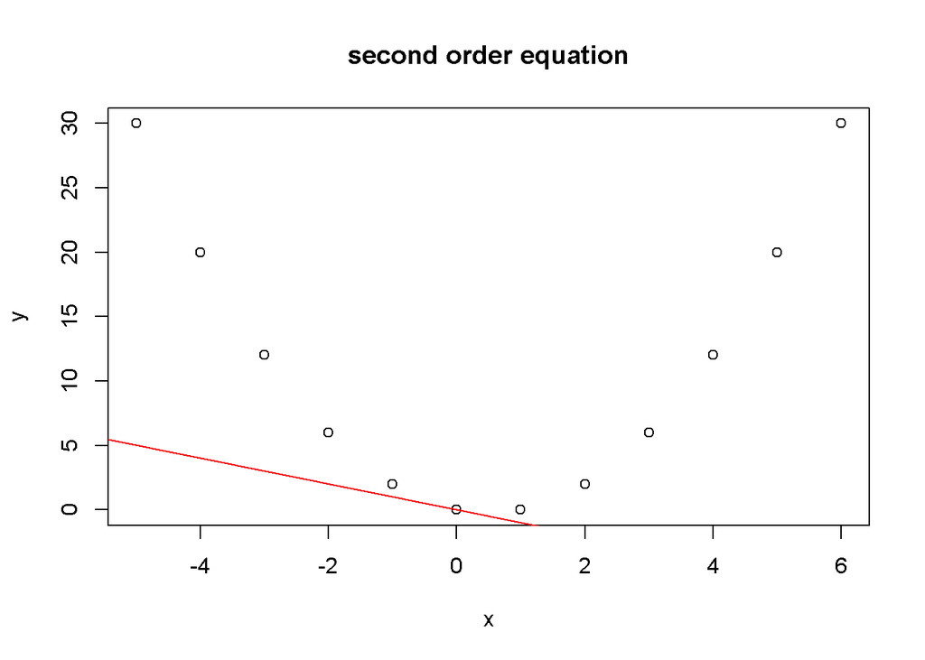

```r
plot(y~x, dfd)
abline(lm(y ~ x + I(x^2), data = dfd), col = "red")
title("second order equation")
```

- actually, we can do it if we do a first order modelling

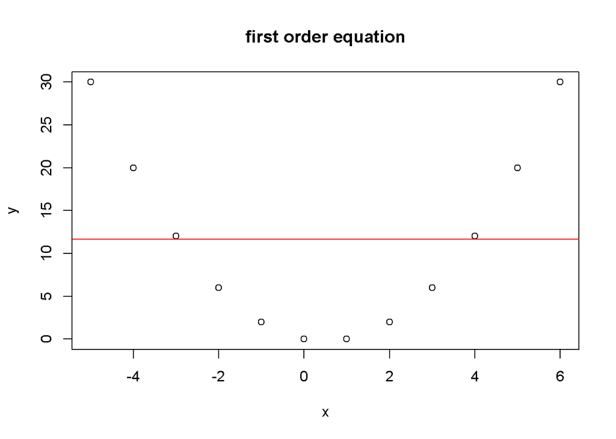

```r
plot(y~x, dfd)
abline(lm(y ~ x, data = dfd), col = "red")
title("first order equation")
```

## 6.2 13 january 2022

- Caracterize changes in numbers:
  - number of species, etc…
  - coefficents per decade
- Plot tendancies by classification category: Jaccard vs richness

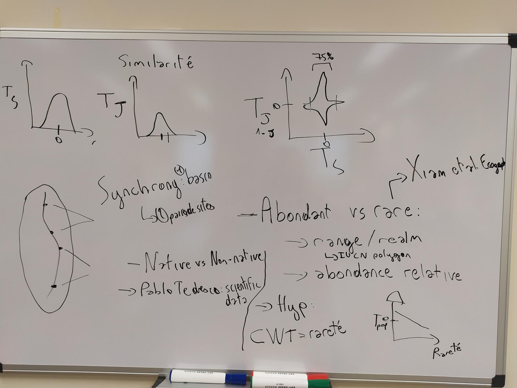

```r
knitr::include_graphics(here::here("doc", "fig", "meeting-2022-01-13.jpeg"))
```

# References

Abell, Robin, Michele L. Thieme, Carmen Revenga, Mark Bryer, Maurice Kottelat, Nina Bogutskaya, Brian Coad, et al. 2008. “Freshwater Ecoregions of the World: A New Map of Biogeographic Units for Freshwater Biodiversity Conservation.” *BioScience* 58 (5): 403–14. https://doi.org/10.1641/B580507.

Baeten, Lander, David I. Warton, Hans Van Calster, Pieter De Frenne, Gorik Verstraeten, Dries Bonte, Markus Bernhardt-Römermann, et al. 2014. “A Model-Based Approach to Studying Changes in Compositional Heterogeneity.” *Methods in Ecology and Evolution* 5 (2): 156–64. https://doi.org/10.1111/2041-210X.12137.

Buckland, Stephen T., Angelika C. Studeny, Anne E. Magurran, Janine B. Illian, and Stuart E. Newson. 2011. “The Geometric Mean of Relative Abundance Indices: A Biodiversity Measure with a Difference.” *Ecosphere* 2 (9): art100. https://doi.org/10.1890/ES11-00186.1.

Cardoso, Pedro, François Rigal, and José C. Carvalho. 2015. “BAT – Biodiversity Assessment Tools, an R Package for the Measurement and Estimation of Alpha and Beta Taxon, Phylogenetic and Functional Diversity.” *Methods in Ecology and Evolution* 6 (2): 232–36. https://doi.org/10.1111/2041-210X.12310.

Chao, Anne, and Lou Jost. 2012. “Coverage-Based Rarefaction and Extrapolation: Standardizing Samples by Completeness Rather Than Size.” *Ecology* 93 (12): 2533–47. https://doi.org/10.1890/11-1952.1.

Collen, Ben, Jonathan Loh, Sarah Whitmee, Louise McRAE, Rajan Amin, and Jonathan E. M. Baillie. 2009. “Monitoring Change in Vertebrate Abundance: The Living Planet Index.” *Conservation Biology* 23 (2): 317–27. https://doi.org/10.1111/j.1523-1739.2008.01117.x.

Comte, Lise, Julian D. Olden, Pablo A. Tedesco, Albert Ruhi, and Xingli Giam. 2021. “Climate and Land-Use Changes Interact to Drive Long-Term Reorganization of Riverine Fish Communities Globally.” *Proceedings of the National Academy of Sciences* 118 (27): e2011639118. https://doi.org/10.1073/pnas.2011639118.

Dornelas, Maria, Nicholas J. Gotelli, Brian McGill, Hideyasu Shimadzu, Faye Moyes, Caya Sievers, and Anne E. Magurran. 2014. “Assemblage Time Series Reveal Biodiversity Change but Not Systematic Loss.” *Science* 344 (6181): 296–99. https://doi.org/10.1126/science.1248484.

Gotelli, Nicholas J., Robert M. Dorazio, Aaron M. Ellison, and Gary D. Grossman. 2010. “Detecting Temporal Trends in Species Assemblages with Bootstrapping Procedures and Hierarchical Models.” *Philosophical Transactions of the Royal Society B: Biological Sciences* 365 (1558): 3621–31. https://doi.org/10.1098/rstb.2010.0262.

Martin, Laura J, Bernd Blossey, and Erle Ellis. 2012. “Mapping Where Ecologists Work: Biases in the Global Distribution of Terrestrial Ecological Observations.” *Frontiers in Ecology and the Environment* 10 (4): 195–201. https://doi.org/10.1890/110154.

McRae, Louise, Stefanie Deinet, and Robin Freeman. 2017. “The Diversity-Weighted Living Planet Index: Controlling for Taxonomic Bias in a Global Biodiversity Indicator.” *PLOS ONE* 12 (1): e0169156. https://doi.org/10.1371/journal.pone.0169156.

Rigal, Stanislas, Vincent Devictor, and Vasilis Dakos. 2020. “A Method for Classifying and Comparing Non-Linear Trajectories of Ecological Variables.” *Ecological Indicators* 112 (May): 106113. https://doi.org/10.1016/j.ecolind.2020.106113.

Shimadzu, Hideyasu, Maria Dornelas, and Anne E. Magurran. 2015. “Measuring Temporal Turnover in Ecological Communities.” Edited by Robert B. O’Hara. *Methods in Ecology and Evolution* 6 (12): 1384–94. https://doi.org/10.1111/2041-210X.12438.

Vaughan, Ian P., and Nicholas J. Gotelli. 2019. “Water Quality Improvements Offset the Climatic Debt for Stream Macroinvertebrates over Twenty Years.” *Nature Communications* 10 (1): 1956. https://doi.org/10.1038/s41467-019-09736-3.

———. 2021. “Using Climatic Credits to Pay the Climatic Debt.” *Trends in Ecology & Evolution* 36 (2): 104–12. https://doi.org/10.1016/j.tree.2020.10.002.

Williams, Jessica J., Robin Freeman, Fiona Spooner, and Tim Newbold. 2021. “Vertebrate Population Trends Are Influenced by Interactions Between Land Use, Climatic Position, Habitat Loss and Climate Change.” *Global Change Biology*, November, gcb.15978. https://doi.org/10.1111/gcb.15978.